# Appendix 4. Data simulation for non central place foragers (NCPF)

Modelling wildlife habitat selection from tracking data: A practical guide for ecologists

# Workspace setup

```r
library(CircStats)
library(terra)
library(sf)
library(ggplot2)
library(pander)
library(doParallel)
library(foreach)

set.seed(1234)
```

# Habitat simulation

The simulation domain was defined as a 2,500 km$^2$ area (50 $\times$ 50 km), discretised into a regular grid with a spatial resolution of 100 m. Habitat suitability was represented as a binary chequerboard pattern consisting of alternating 2.5 $\times$ 2.5 km cells, classified as suitable (value = 1) and unsuitable (value = 0).

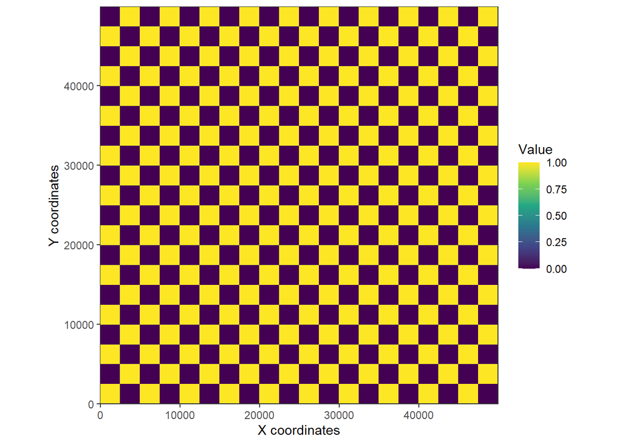

```r
# Define grid in meters: 100 m resolution over 50 km
x_grid <- seq(0, by = 100, length.out = 500)  # 0 to 50,000 meters
y_grid <- seq(0, by = 100, length.out = 500)

# Create coordinate grid
coord_df <- expand.grid(x = x_grid, y = y_grid)

# Checkerboard pattern with 2.5 km squares
x_band <- floor(coord_df$x / 2500) %% 2
y_band <- floor(coord_df$y / 2500) %% 2


df <- data.frame(
  x = coord_df$x,
  y = coord_df$y,
  value = (x_band == y_band) + 0
)

df$value <- (df$value - min(df$value)) / (max(df$value) - min(df$value))

# terra raster
cov_raster <- rast(
  df,
  type = "xyz",
  crs = "EPSG:32630"
)

writeRaster(cov_raster, "cov_raster.tif", overwrite = TRUE)

ggplot(df, aes(x = x, y = y, fill = value)) +
  geom_tile() +
  labs(fill = "Value") +
  xlab("X coordinates")+
  ylab("Y coordinates") +
  scale_fill_viridis_c()+
  coord_fixed(expand = FALSE) +
  theme_bw()
```

# Movement simulation

### Behavioural states

Animal movement was modelled using a three-state behavioural framework designed to capture the main movement modes of non-central place foragers, which do not undertake directed trips to or from a central location. Specifically, State 1 (travelling) represents fast, directed movement; State 2 (search) corresponds to moderately fast movement with some directional persistence; and State 3 (foraging) reflects slower, more tortuous movement associated with intensive resource use. Transitions between behavioural states were influenced by habitat conditions, such that individuals were more likely to enter search (State 2) or foraging (State 3) when in suitable habitat, and more likely to leave the foraging state as habitat suitability decreased or as time increased.

### State transition model

$$T =
\begin{pmatrix}
1 - p_{12} & p_{12} & 0 \\
0 & 1 - p_{23} & p_{23} \\
r_{31} & r_{32} & r_{33}
\end{pmatrix}$$

where $p_{12}$ corresponds to switching from travelling $\rightarrow$ searching, $p_{23}$ searching $\rightarrow$ foraging and $r_{31}, r_{32}, r_{33}$ the transitions from foraging to other states.

We defined:

$$p_{12} =
\text{logit}^{-1}(\eta_{12})$$
$$p_{23} = \text{logit}^{-1}(\eta_{23})$$
$$r_{31} = \frac{e^{\eta_{31}}}{1 +
e^{\eta_{31}} + e^{\eta_{32}}}$$
$$r_{32} = \frac{e^{\eta_{32}}}{1 + e^{\eta_{31}} +
e^{\eta_{32}}}$$
$$r_{33} = 1 - r_{31}
- r_{32}$$

The linear predictors were specified as:

$$\eta_{12} = -2 + 1.5 \cdot \text{Habitat}$$

$$\eta_{23} = -1.5 + 3 \cdot \text{Habitat}$$

$$\eta_{31} = -3 - 3 \cdot \text{Habitat} + 0.05 \cdot \text{Time}$$

$$\eta_{32} = -3 - 1.5 \cdot \text{Habitat} + 0.05 \cdot \text{Time}$$

```r
# -------------------------------------------------------------
# Transition matrix
# ------------------------------------------------------------
addLogit_rcpp <- function(x1, x2) {
  p1 <- exp(x1)
  p2 <- exp(x2)
  res <- c(p1 / (1 + p1 + p2), p2 / (1 + p1 + p2), 1 - (p1 / (1 + p1 + p2)) - (p2 / (1 + p1 + p2)))
  return(res)
}

trMatrix_rcpp <- function(beta, time, cov) {
  trMat <- matrix(ncol = 3, nrow = 3)

  # From State 1
  p12 <- plogis(beta[1] + beta[2] * cov)
  trMat[1, 1] <- 1 - p12
  trMat[1, 2] <- p12
  trMat[1, 3] <- 0

  # From State 2
  p23 <- plogis(beta[3] + beta[4] * cov)
  trMat[2, 1] <- 0
  trMat[2, 2] <- 1 - p23
  trMat[2, 3] <- p23

  # From State 3
  p31 <- beta[5] + beta[6] * cov + beta[7] * time
  p32 <- beta[8] + beta[9] * cov + beta[10] * time
  r3 <- addLogit_rcpp(p31, p32)


  trMat[3, 1] <- r3[1]
  trMat[3, 2] <- r3[2]
  trMat[3, 3] <- r3[3]

  return(trMat)
}

# HMM transition coefficients
addLogit_rcpp <- function(x1, x2) {
  p1 <- exp(x1)
  p2 <- exp(x2)
  res <- c(p1 / (1 + p1 + p2), p2 / (1 + p1 + p2), 1 - (p1 / (1 + p1 + p2)) - (p2 / (1 + p1 + p2)))
  return(res)
}

trMatrix_rcpp <- function(beta, time, cov) {
  trMat <- matrix(ncol = 3, nrow = 3)

  # From State 1
  p12 <- plogis(beta[1] + beta[2] * cov)
  trMat[1, 1] <- 1 - p12
  trMat[1, 2] <- p12
  trMat[1, 3] <- 0

  # From State 2
  p23 <- plogis(beta[3] + beta[4] * cov)
  trMat[2, 1] <- 0
  trMat[2, 2] <- 1 - p23
  trMat[2, 3] <- p23

  # From State 3
  p31 <- beta[5] + beta[6] * cov + beta[7] * time
  p32 <- beta[8] + beta[9] * cov + beta[10] * time
  r3 <- addLogit_rcpp(p31, p32)


  trMat[3, 1] <- r3[1]
  trMat[3, 2] <- r3[2]
  trMat[3, 3] <- r3[3]

  return(trMat)
}

# HMM transition coefficients
beta <- c(
  -2, 1.5,        # State 1 → 2
  -1.5, 3,      # State 2 → 3
  -3, -3, 0.05,  # State 3 → 1
  -3, -1.5, 0.05  # State 3 → 2
)
```

Higher habitat suitability increased the probability of transitioning into search and foraging states, whereas the likelihood of leaving the foraging state increased with time spent within a patch. This transition structure captures realistic patch-use dynamics typical of non-central place foragers.

### State-specific parameters

State-specific behaviours process were modelled as correlated random walks, with associated parameters varying among behavioural states. Step lengths and turning angles were modelled using gamma and von Mises distributions, respectively, with state-specific parameter values.

[output not shown]

```r
mu <- c(571.8, 350, 108)
sigma <- c(195.4, 190, 131.2)
am <- c(0, -0.00647766, pi)
kappa <- c(8, 5, 0.84)
nbStates <- 3
```

### Step selection

At each time step, we drew 10,000 candidate steps from the movement kernel associated with the current behavioural state. We calculated a relative selection weight for each candidate by exponentiating the linear predictor and then selected one end point probabilistically as the animal’s next location. Each candidate step $i$ was evaluated using a log‑linear model of the form:

$$\log(w_i) = \beta_1 \times L_i + \beta_2 \times \log L_i + \beta_3
\times h_i$$

$$w_i = \exp(\eta_i) \quad \mathrm{Pr}(i) = \frac{\exp(\eta_i)}{\sum_j
\exp(\eta_j)}$$

where $L_i$ is the step length, $h_i$ is the habitat covariate and $\beta_1, \beta_2$ and $\beta_3$ are the corresponding selection coefficients.

Individuals were initialised at a random location within the simulation area at time $t = 0$, with the first step generated by drawing a direction $\phi_0 \sim \mathrm{von\ Mises}(0, 1)$ and a step length $L_0 \sim \mathrm{Gamma}(k, \theta)$. The latter was parameterised in terms of the state-specific mean $\mu$ and standard deviation $\sigma$ for travel, such that $k = \mu^2 / \sigma^2$ and $\theta = \sigma^2 / \mu$. The resulting displacement defines the first location.

```r
### SSF parameters
# Equations exist to determine the scale and shape parameters of a gamma distribution
# based on its mean and sd
gamma_shape <- mu^2 / sigma^2
gamma_scale <- sigma^2 / mu

# The equation presented in Appendix A gives the relationship between the
# gamma distribution parameters and the selection coefficients (referred to as β1 and β2 for L and log(L) respectively).
# β1 −1/scale and β2 = shape − 2.
beta1 <- -1 / gamma_scale
beta2 <- gamma_shape - 2

cov_beta <- 1 #0.5, 0.75, 1, 1.25, 1.5, 1.75,2

ssf_formula <- as.formula(" ~ cov")
n_zeros <- 10000
```

### Simulate animal tracks

We simulate a full population of 1,000 individuals and one track per individual with duration of 360 minutes.

```r
nbTracks <- 1
nbID <- 1000
track_duration<-360

simulate_individual <- function(id){
  cov_raster <- terra::rast("cov_raster.tif")
  track_data <- NULL

  state <- 1

  phi <- rvm(1, 0, 1)

  len <- rgamma(
    1,
    shape = gamma_shape[state],
    scale = gamma_scale[state]
  )

  centre <- c(
    sample(seq(500,48500,100),1),
    sample(seq(500,48500,100),1)
  )

  newLoc <- centre + c(
    len*cos(phi),
    len*sin(phi)
  )

  while(
    !(
      newLoc[1] >= 100 &
      newLoc[1] <= 49900 &
      newLoc[2] >= 100 &
      newLoc[2] <= 49900
    )
  ){

    centre <- c(
      sample(seq(500,48500,100),1),
      sample(seq(500,48500,100),1)
    )

    newLoc <- centre + c(
      len*cos(phi),
      len*sin(phi)
    )
  }

  track_data <- data.frame(
    x = centre[1],
    y = centre[2],
    step = NA,
    angle = NA,
    bearing = NA,
    state = 1,
    time = 0,
    ID = id
  )

  time <- 0

  while(time < track_duration){

    time <- time + 1

    phi0 <- phi

    cov <- terra::extract(
      cov_raster,
      matrix(newLoc,nrow=1)
    )[1,1]

    trMat <- trMatrix_rcpp(
      beta,
      time,
      cov
    )

    state <- sample(
      1:nbStates,
      1,
      prob = trMat[state,]
    )

    angle_candidates <- rvm(
      n_zeros,
      mean = am[state],
      k = kappa[state]
    )

    phi_candidates <- phi + angle_candidates

    len_candidates <- rgamma(
      n_zeros,
      shape = gamma_shape[state],
      scale = gamma_scale[state]
    )

    endpoints <- cbind(
      newLoc[1] +
        len_candidates*cos(phi_candidates),
      newLoc[2] +
        len_candidates*sin(phi_candidates)
    )

    inside <- endpoints[,1] >= 100 &
      endpoints[,1] <= 49900 &
      endpoints[,2] >= 100 &
      endpoints[,2] <= 49900

    if(sum(inside)==0) next

    endpoints <- endpoints[inside,,drop=FALSE]
    phi_candidates <- phi_candidates[inside]
    len_candidates <- len_candidates[inside]

    cov_vals <- terra::extract(
      cov_raster,
      endpoints
    )[,1]

    linear_pred <-
      cov_vals * ssf_betas[4,state]

    ssf_prob <- exp(linear_pred)

    ssf_prob <- ssf_prob/sum(ssf_prob)

    chosen <- sample(
      seq_len(nrow(endpoints)),
      1,
      prob = ssf_prob
    )

    newLoc <- endpoints[chosen,]
    phi <- phi_candidates[chosen]
    len <- len_candidates[chosen]

    track_data <- rbind(
      track_data,
      data.frame(
        x = newLoc[1],
        y = newLoc[2],
        step = len,
        angle = phi - phi0,
        bearing = phi,
        state = state,
        time = time,
        ID = id
      )
    )
  }

  track_data
}

runtime <- system.time({

ncores <- parallel::detectCores() - 1
cl <- makeCluster(ncores)
registerDoParallel(cl)


for(c in 1:length(cov_beta)){
  cov_gamma <- rep(1, 3)
  cov_coefs <- cov_beta[c] * cov_gamma

  ssf_betas <- matrix(c(beta1, beta2, kappa, cov_coefs),
                      ncol = nbStates, byrow = TRUE)


  data <- NULL

data <- foreach(
    id = seq_len(nbID),
    .combine  = rbind,
    .packages = c("CircStats", "terra"),
    .export   = c(
      "simulate_individual",
      "trMatrix_rcpp",
      "cov_raster",
      "ssf_betas",
      "ssf_formula",
      "mu", "sigma", "kappa", "am",
      "beta",
      "nbTracks",
      "nbStates",
      "n_zeros")
  ) %dopar% {

  simulate_individual(id)

}
  # Convert to sf
  data_sf <- st_as_sf(data, coords = c("x", "y"), crs = 32630)

  # Save only the data object
  save(data_sf, file = paste0("NCPF_cov", cov_beta[c], "_", nbID, "ind.RData"))
  }
})
```

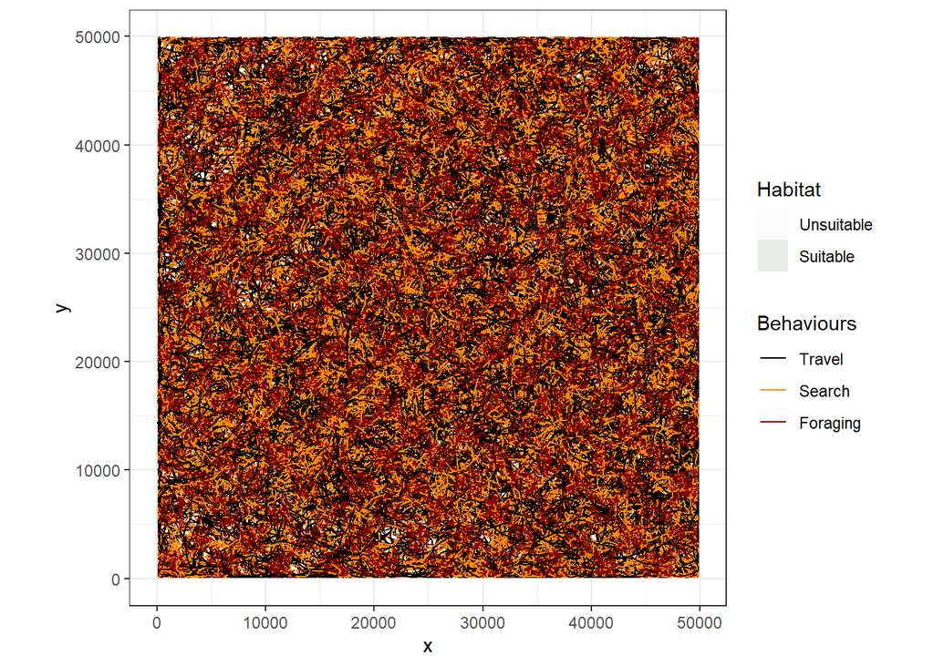

```r
# plot tracks
ggplot() +
  geom_tile(data=df, aes(x,y,fill=factor(value)), alpha=0.1)+
  geom_path(data= data, aes(x, y, col= factor(state), group = ID)) +
  scale_fill_manual(values = c("lightgrey", "darkgreen"), name = "Habitat", labels=c("Unsuitable", "Suitable"))+
  scale_colour_manual(values = c("black", "darkorange", "darkred"), name = "Behaviours", labels=c("Travel", "Search", "Foraging"))+
  theme_bw() +
  coord_fixed()
```

# Computational performance

Simulation time was measured using the `system.time()` function in R. A total of 1 habitat-selection scenarios were evaluated. For each scenario, 1 complete tracks with 360 were generated for each of 1,000 simulated individuals. The complete simulation required 92.69 minutes (elapsed time) and was executed in parallel using 7 CPU cores.

For reproducibility, the session information corresponding to the computational environment used for these simulations, including the R version, operating system, and package versions, is provided below.

[session information not shown]

**R version 4.6.0 (2026-04-24 ucrt)**

**Platform:** x86_64-w64-mingw32/x64

**locale:** *LC_COLLATE=English_United Kingdom.utf8*, *LC_CTYPE=English_United Kingdom.utf8*, *LC_MONETARY=English_United Kingdom.utf8*, *LC_NUMERIC=C* and *LC_TIME=English_United Kingdom.utf8*

**attached base packages:** *parallel*, *stats*, *graphics*, *grDevices*, *utils*, *datasets*, *methods* and *base*

**other attached packages:** *doParallel(v.1.0.17)*, *iterators(v.1.0.14)*, *foreach(v.1.5.2)*, *pander(v.0.6.6)*, *ggplot2(v.4.0.3)*, *sf(v.1.1-2)*, *terra(v.1.9-34)*, *CircStats(v.0.2-7)*, *boot(v.1.3-32)* and *MASS(v.7.3-65)*

**loaded via a namespace (and not attached):** *sass(v.0.4.10)*, *generics(v.0.1.4)*, *class(v.7.3-23)*, *KernSmooth(v.2.23-26)*, *digest(v.0.6.39)*, *magrittr(v.2.0.5)*, *evaluate(v.1.0.5)*, *grid(v.4.6.0)*, *RColorBrewer(v.1.1-3)*, *fastmap(v.1.2.0)*, *jsonlite(v.2.0.0)*, *e1071(v.1.7-17)*, *DBI(v.1.3.0)*, *viridisLite(v.0.4.3)*, *scales(v.1.4.0)*, *codetools(v.0.2-20)*, *jquerylib(v.0.1.4)*, *cli(v.3.6.6)*, *rlang(v.1.3.0)*, *units(v.1.0-1)*, *withr(v.3.0.3)*, *cachem(v.1.1.0)*, *yaml(v.2.3.12)*, *otel(v.0.2.0)*, *tools(v.4.6.0)*, *dplyr(v.1.2.1)*, *vctrs(v.0.7.3)*, *R6(v.2.6.1)*, *proxy(v.0.4-29)*, *lifecycle(v.1.0.5)*, *classInt(v.0.4-11)*, *pkgconfig(v.2.0.3)*, *bslib(v.0.12.0)*, *pillar(v.1.11.1)*, *gtable(v.0.3.6)*, *glue(v.1.8.1)*, *Rcpp(v.1.1.2)*, *xfun(v.0.60)*, *tibble(v.3.3.1)*, *tidyselect(v.1.2.1)*, *knitr(v.1.51)*, *farver(v.2.1.2)*, *htmltools(v.0.5.9)*, *labeling(v.0.4.3)*, *rmarkdown(v.2.31)*, *compiler(v.4.6.0)* and *S7(v.0.2.2)*

## References Avgar, Tal, Jonathan R Potts, Mark A Lewis, and Mark S Boyce. 2016. “Integrated Step Selection Analysis: Bridging the Gap Between Resource Selection and Animal Movement.” *Methods in Ecology and Evolution* 7 (5): 619–30. https://doi.org/10.1111/2041-210x.12528. Hijmans, Robert J. 2026. *Geosphere: Spherical Trigonometry*. Klappstein, N J, L Thomas, and T Michelot. 2023. “Flexible Hidden Markov Models for Behaviour-Dependent Habitat Selection.” *Movement Ecology* 11 (1): 30. https://doi.org/10.1186/s40462-023-00392-3. Michelot, Théo, Roland Langrock, Sophie Bestley, Ian D Jonsen, Theoni Photopoulou, and Toby A Patterson. 2017. “Estimation and Simulation of Foraging Trips in Land-Based Marine Predators.” *Ecology* 98 (7): 1932–44. https://doi.org/10.1002/ecy.1880.